# Practical Machine Learning Project Report - Human Activity Recognition - Weight Lifting

Youyi Liu

8/23/2019

# 1.Introduction

Our data in this case comes from the research on the human activity recognition. The purpose of this research is using recorded sensor data to predict the actual action of the users. The research is conducted by Wallace Ugulino, Eduardo Velloso and Hugo Fuks. The detail of this research could be reached at http://groupware.les.inf.puc-rio.br/har.

In this case, the project is using sensor data to predict the real action in a weight lifting scenario. The actions include:

```
##      classe Description
## [1,] "A"    "Exactly according to the specification"
## [2,] "B"    "Throwing the elbows to the front"
## [3,] "C"    "lifting the dumbbell only halfway"
## [4,] "D"    "Lowering the dumbbell only halfway"
## [5,] "E"    "Throwing the hips to the front"
```

The dataset record data from 4 different positions of a Weight lifting exercise: arm, forearm, belt(waist) and the dumbbell.

# 2.Data Exploration & Preparation

First we load the data into our data base

```
## [1] 19622   160
```

```
## [1]  20 160
```

There are 160 columns of metrics and 19622 rows of observations in the training data set and the testset has the same columns of metrics but 20 observations. In other word, the trainset has 99.9% and the testset has 0.1% of the total data. So I consider the testset as the final test set and conducting cross validation in the trainset.

### 2.1 Refine Metrics

Before we dive deep into the dataset, we should have a better understand of the columns. The data has four main measurements, which are sensors located seperatedly:

the glove(forearm):

```
##  [1] "roll_forearm"            "pitch_forearm"
##  [3] "yaw_forearm"             "kurtosis_roll_forearm"
##  [5] "kurtosis_picth_forearm"  "kurtosis_yaw_forearm"
##  [7] "skewness_roll_forearm"   "skewness_pitch_forearm"
##  [9] "skewness_yaw_forearm"    "max_roll_forearm"
## [11] "max_picth_forearm"       "max_yaw_forearm"
## [13] "min_roll_forearm"        "min_pitch_forearm"
## [15] "min_yaw_forearm"         "amplitude_roll_forearm"
## [17] "amplitude_pitch_forearm" "amplitude_yaw_forearm"
## [19] "total_accel_forearm"     "var_accel_forearm"
## [21] "avg_roll_forearm"        "stddev_roll_forearm"
## [23] "var_roll_forearm"        "avg_pitch_forearm"
## [25] "stddev_pitch_forearm"    "var_pitch_forearm"
## [27] "avg_yaw_forearm"         "stddev_yaw_forearm"
## [29] "var_yaw_forearm"         "gyros_forearm_x"
## [31] "gyros_forearm_y"         "gyros_forearm_z"
## [33] "accel_forearm_x"         "accel_forearm_y"
## [35] "accel_forearm_z"         "magnet_forearm_x"
## [37] "magnet_forearm_y"        "magnet_forearm_z"
```

the arm-band(arm):

```
##  [1] "roll_arm"            "pitch_arm"           "yaw_arm"
##  [4] "total_accel_arm"     "var_accel_arm"       "avg_roll_arm"
##  [7] "stddev_roll_arm"     "var_roll_arm"        "avg_pitch_arm"
## [10] "stddev_pitch_arm"    "var_pitch_arm"       "avg_yaw_arm"
## [13] "stddev_yaw_arm"      "var_yaw_arm"         "gyros_arm_x"
## [16] "gyros_arm_y"         "gyros_arm_z"         "accel_arm_x"
## [19] "accel_arm_y"         "accel_arm_z"         "magnet_arm_x"
## [22] "magnet_arm_y"        "magnet_arm_z"        "kurtosis_roll_arm"
## [25] "kurtosis_picth_arm"  "kurtosis_yaw_arm"    "skewness_roll_arm"
## [28] "skewness_pitch_arm"  "skewness_yaw_arm"    "max_roll_arm"
## [31] "max_picth_arm"       "max_yaw_arm"         "min_roll_arm"
## [34] "min_pitch_arm"       "min_yaw_arm"         "amplitude_roll_arm"
## [37] "amplitude_pitch_arm" "amplitude_yaw_arm"
```

the belt:

```
##  [1] "roll_belt"            "pitch_belt"           "yaw_belt"
##  [4] "total_accel_belt"     "kurtosis_roll_belt"   "kurtosis_picth_belt"
##  [7] "kurtosis_yaw_belt"    "skewness_roll_belt"   "skewness_roll_belt.1"
## [10] "skewness_yaw_belt"    "max_roll_belt"        "max_picth_belt"
## [13] "max_yaw_belt"         "min_roll_belt"        "min_pitch_belt"
## [16] "min_yaw_belt"         "amplitude_roll_belt"  "amplitude_pitch_belt"
## [19] "amplitude_yaw_belt"   "var_total_accel_belt" "avg_roll_belt"
## [22] "stddev_roll_belt"     "var_roll_belt"        "avg_pitch_belt"
## [25] "stddev_pitch_belt"    "var_pitch_belt"       "avg_yaw_belt"
## [28] "stddev_yaw_belt"      "var_yaw_belt"         "gyros_belt_x"
## [31] "gyros_belt_y"         "gyros_belt_z"         "accel_belt_x"
## [34] "accel_belt_y"         "accel_belt_z"         "magnet_belt_x"
## [37] "magnet_belt_y"        "magnet_belt_z"
```

the dumbbell:

```
##  [1] "roll_dumbbell"            "pitch_dumbbell"
##  [3] "yaw_dumbbell"             "kurtosis_roll_dumbbell"
##  [5] "kurtosis_picth_dumbbell"  "kurtosis_yaw_dumbbell"
##  [7] "skewness_roll_dumbbell"   "skewness_pitch_dumbbell"
##  [9] "skewness_yaw_dumbbell"    "max_roll_dumbbell"
## [11] "max_picth_dumbbell"       "max_yaw_dumbbell"
## [13] "min_roll_dumbbell"        "min_pitch_dumbbell"
## [15] "min_yaw_dumbbell"         "amplitude_roll_dumbbell"
## [17] "amplitude_pitch_dumbbell" "amplitude_yaw_dumbbell"
## [19] "total_accel_dumbbell"     "var_accel_dumbbell"
## [21] "avg_roll_dumbbell"        "stddev_roll_dumbbell"
## [23] "var_roll_dumbbell"        "avg_pitch_dumbbell"
## [25] "stddev_pitch_dumbbell"    "var_pitch_dumbbell"
## [27] "avg_yaw_dumbbell"         "stddev_yaw_dumbbell"
## [29] "var_yaw_dumbbell"         "gyros_dumbbell_x"
## [31] "gyros_dumbbell_y"         "gyros_dumbbell_z"
## [33] "accel_dumbbell_x"         "accel_dumbbell_y"
## [35] "accel_dumbbell_z"         "magnet_dumbbell_x"
## [37] "magnet_dumbbell_y"        "magnet_dumbbell_z"
```

There are 38 columns each describing the data gathered from the 4 sensors. 160 - 38*4 = 8.

There are 8 columns left including:

```
## [1] "X"                    "user_name"            "raw_timestamp_part_1"
## [4] "raw_timestamp_part_2" "cvtd_timestamp"       "new_window"
## [7] "num_window"           "classe"
```

Classe would be our prediction variable.

```
##  classe
##  A:5580
##  B:3797
##  C:3422
##  D:3216
##  E:3607
```

raw_timestamp_part1, raw_timestamp_part2 and cvtd_timestamp could be treated as one.

```
##  raw_timestamp_part_1 raw_timestamp_part_2          cvtd_timestamp
##  Min.   :1.322e+09    Min.   :   294       28/11/2011 14:14: 1498
##  1st Qu.:1.323e+09    1st Qu.:252912       05/12/2011 11:24: 1497
##  Median :1.323e+09    Median :496380       30/11/2011 17:11: 1440
##  Mean   :1.323e+09    Mean   :500656       05/12/2011 11:25: 1425
##  3rd Qu.:1.323e+09    3rd Qu.:751891       02/12/2011 14:57: 1380
##  Max.   :1.323e+09    Max.   :998801       02/12/2011 13:34: 1375
##                                            (Other)         :11007
```

X stands for the number of rows.

new_window and num_window represent the if the time window was the first one and the series number of windows, and thus could be ignored:

```
##        X         new_window    num_window
##  Min.   :    1   no :19216   Min.   :  1.0
##  1st Qu.: 4906   yes:  406   1st Qu.:222.0
##  Median : 9812               Median :424.0
##  Mean   : 9812               Mean   :430.6
##  3rd Qu.:14717               3rd Qu.:644.0
##  Max.   :19622               Max.   :864.0
```

Therefore, the predictors could be divided into 5 main groups:

different user(user_name),

glove sensor parameters (“forearm” group),

arm-band sensor parameters(“arm” group),

belt sensor parameters(“belt” group),

dumbbell sensor parameters(“dumbbell” group).

### 2.2 Data Cleaning

Then we need to dive into the Features and select the most useful predictors, to filter out useless variables.

In each group of sensor data, there are 38 variables included.

The Euler Angles(roll, pitch and yaw) readings are recorded as same as 8 features(mean, variance, standard deviation, max, min, amplitude, kurtosis and skewness). 3 + 3*8 = 27

The accelerometer reading of Cartesian coordinate readings(x,y,z) are recorded as same as 2 features(total and variance). 3 + 2 = 5

The gyroscope’s and magnetometer’s cartesion coordinate readings(x,y,z) 3

The magnetometer’s cartesion coordinate readings(x,y,z) 3

The total is 27 + 5 + 3 + 3 = 38

Some of them may be highly related.

We look closely into the data in the forearm data as an example:

```
##  kurtosis_roll_forearm kurtosis_picth_forearm kurtosis_yaw_forearm
##         :19216                :19216                 :19216
##  #DIV/0!:   84         #DIV/0!:   85          #DIV/0!:  406
##  -0.8079:    2         -0.0073:    1
##  -0.9169:    2         -0.0442:    1
##  -0.0227:    1         -0.0489:    1
##  -0.0359:    1         -0.0523:    1
##  (Other):  316         (Other):  317
##  skewness_roll_forearm skewness_pitch_forearm skewness_yaw_forearm
##         :19216                :19216                 :19216
##  #DIV/0!:   83         #DIV/0!:   85          #DIV/0!:  406
##  -0.1912:    2         0.0000 :    4
##  -0.4126:    2         -0.6992:    2
##  -0.0004:    1         -0.0113:    1
##  -0.0013:    1         -0.0131:    1
##  (Other):  317         (Other):  313
##  max_roll_forearm max_picth_forearm max_yaw_forearm min_roll_forearm
##  Min.   :-66.60   Min.   :-151.00          :19216   Min.   :-72.500
##  1st Qu.:  0.00   1st Qu.:   0.00   #DIV/0!:   84   1st Qu.: -6.075
##  Median : 26.80   Median : 113.00   -1.2   :   32   Median :  0.000
##  Mean   : 24.49   Mean   :  81.49   -1.3   :   31   Mean   : -0.167
##  3rd Qu.: 45.95   3rd Qu.: 174.75   -1.4   :   24   3rd Qu.: 12.075
##  Max.   : 89.80   Max.   : 180.00   -1.5   :   24   Max.   : 62.100
##  NA's   :19216    NA's   :19216     (Other):  211   NA's   :19216
##  min_pitch_forearm min_yaw_forearm amplitude_roll_forearm
##  Min.   :-180.00          :19216   Min.   :  0.000
##  1st Qu.:-175.00   #DIV/0!:   84   1st Qu.:  1.125
##  Median : -61.00   -1.2   :   32   Median : 17.770
##  Mean   : -57.57   -1.3   :   31   Mean   : 24.653
##  3rd Qu.:   0.00   -1.4   :   24   3rd Qu.: 39.875
##  Max.   : 167.00   -1.5   :   24   Max.   :126.000
##  NA's   :19216     (Other):  211   NA's   :19216
##  amplitude_pitch_forearm amplitude_yaw_forearm var_accel_forearm
##  Min.   :  0.0                  :19216         Min.   :  0.000
##  1st Qu.:  2.0           #DIV/0!:   84         1st Qu.:  6.759
##  Median : 83.7           0.00   :  322         Median : 21.165
##  Mean   :139.1                                 Mean   : 33.502
##  3rd Qu.:350.0                                 3rd Qu.: 51.240
##  Max.   :360.0                                 Max.   :172.606
##  NA's   :19216                                 NA's   :19216
```

[output cut: 9 more lines]

```
##  Min.   :-68.17    Min.   : 0.000       Min.   :   0.000
##  1st Qu.:  0.00    1st Qu.: 0.336       1st Qu.:   0.113
##  Median : 12.02    Median : 5.516       Median :  30.425
##  Mean   : 11.79    Mean   : 7.977       Mean   : 139.593
##  3rd Qu.: 28.48    3rd Qu.:12.866       3rd Qu.: 165.532
##  Max.   : 72.09    Max.   :47.745       Max.   :2279.617
##  NA's   :19216     NA's   :19216        NA's   :19216
##  avg_yaw_forearm   stddev_yaw_forearm var_yaw_forearm
##  Min.   :-155.06   Min.   :  0.000    Min.   :    0.00
##  1st Qu.: -26.26   1st Qu.:  0.524    1st Qu.:    0.27
##  Median :   0.00   Median : 24.743    Median :  612.21
##  Mean   :  18.00   Mean   : 44.854    Mean   : 4639.85
##  3rd Qu.:  85.79   3rd Qu.: 85.817    3rd Qu.: 7368.41
##  Max.   : 169.24   Max.   :197.508    Max.   :39009.33
##  NA's   :19216     NA's   :19216      NA's   :19216
```

There are 25 factor variables out of 38 in this dataset have little information. These variables have almost 98% none recorded data, NAs and only 2% of the information are recorded. Then these variables should be dropped from the candidates of variables before conducting a feature selection. The same cleanning strategies are applied to other groups of data. The cleaned dataset has the following structure:

```
## 'data.frame':    19622 obs. of  54 variables:
##  $ user_name           : Factor w/ 6 levels "adelmo","carlitos",..: 2 2 2 2 2 2 2 2 2 2 ...
##  $ roll_belt           : num  1.41 1.41 1.42 1.48 1.48 1.45 1.42 1.42 1.43 1.45 ...
##  $ pitch_belt          : num  8.07 8.07 8.07 8.05 8.07 8.06 8.09 8.13 8.16 8.17 ...
##  $ yaw_belt            : num  -94.4 -94.4 -94.4 -94.4 -94.4 -94.4 -94.4 -94.4 -94.4 -94.4 ...
##  $ total_accel_belt    : int  3 3 3 3 3 3 3 3 3 3 ...
##  $ gyros_belt_x        : num  0 0.02 0 0.02 0.02 0.02 0.02 0.02 0.02 0.03 ...
##  $ gyros_belt_y        : num  0 0 0 0 0.02 0 0 0 0 0 ...
##  $ gyros_belt_z        : num  -0.02 -0.02 -0.02 -0.03 -0.02 -0.02 -0.02 -0.02 -0.02 0 ...
##  $ accel_belt_x        : int  -21 -22 -20 -22 -21 -21 -22 -22 -20 -21 ...
##  $ accel_belt_y        : int  4 4 5 3 2 4 3 4 2 4 ...
##  $ accel_belt_z        : int  22 22 23 21 24 21 21 21 24 22 ...
##  $ magnet_belt_x       : int  -3 -7 -2 -6 -6 0 -4 -2 1 -3 ...
##  $ magnet_belt_y       : int  599 608 600 604 600 603 599 603 602 609 ...
##  $ magnet_belt_z       : int  -313 -311 -305 -310 -302 -312 -311 -313 -312 -308 ...
```

[output cut: 40 more lines]

After these cleaning have been done, we would also notice that the variables comes from the same group may be highly correlated, hence bias in the prediction. Therefore, we may consider doing the regularization regression in the model at this point.

### 2.3 Cross validation

In order to detect relevant parameters and leave the testset untouched before final test, we will go a cross validation process on our trainset. Using cross validation will help in avoiding over-ftting. k-fold cross validation was took into consideration.

In particular, 10-fold cross validation was picked for use, making the training set splited into 9 testsets and 1 validation set for training 10 times, each fold was used for validation set once. 5-fold cross validation will be considered. Since increasing the folds of cross validation will increase the accuracy for sure but will also increase the variance. Therefore, to find the large enough fold number we try setting two sets of k-fold cross validation here.

```r
library(caret)
train_control10 <- trainControl(method = "CV", number = 10)
train_control5 <- trainControl(method = "CV", number = 5)
```

Running simple Decision Tree models will help us choose the k’s value in cross validation

```
## CART
##
## 19622 samples
##    53 predictor
##     5 classes: 'A', 'B', 'C', 'D', 'E'
##
## No pre-processing
## Resampling: Cross-Validated (5 fold)
## Summary of sample sizes: 15697, 15698, 15698, 15698, 15697
## Resampling results across tuning parameters:
##
##   cp          Accuracy   Kappa
##   0.03567868  0.5091225  0.35899938
##   0.05998671  0.4165651  0.20887860
##   0.11515454  0.3316734  0.07205976
##
## Accuracy was used to select the optimal model using the largest value.
## The final value used for the model was cp = 0.03567868.
```

```
## CART
##
## 19622 samples
##    53 predictor
##     5 classes: 'A', 'B', 'C', 'D', 'E'
##
## No pre-processing
## Resampling: Cross-Validated (10 fold)
## Summary of sample sizes: 17661, 17661, 17660, 17660, 17659, 17659, ...
## Resampling results across tuning parameters:
##
##   cp          Accuracy   Kappa
##   0.03567868  0.5013253  0.34858070
##   0.05998671  0.4417368  0.25129539
##   0.11515454  0.3237265  0.05992685
##
## Accuracy was used to select the optimal model using the largest value.
## The final value used for the model was cp = 0.03567868.
```

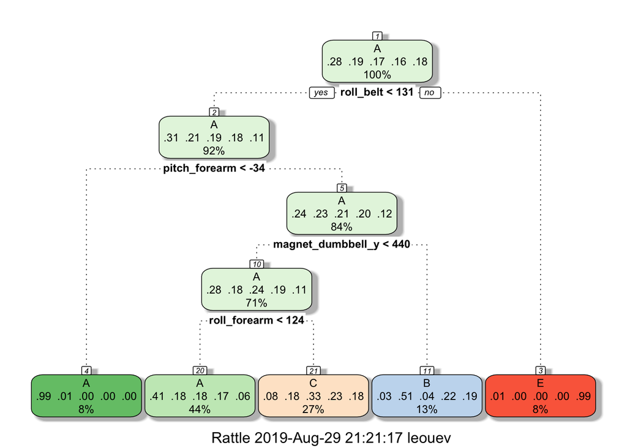

We can see that from 5 to 10 folds, the Accuracy does not increase too much between the two models above. 5-fold cross validation is accurate enough in our modeling. Then we will use a 5-fold cross validation in the following modeling process.

## 3. Training Models and Validations

To find the most fitted model, several models are used for exploration. To control bias in different variables, each model will have a preprocess that normalizing the variables.

### 3.1 Gradient Boosting classification

```
## Stochastic Gradient Boosting
##
## 19622 samples
##    53 predictor
##     5 classes: 'A', 'B', 'C', 'D', 'E'
##
## Pre-processing: centered (57), scaled (57)
## Resampling: Cross-Validated (5 fold)
## Summary of sample sizes: 15697, 15699, 15696, 15699, 15697
## Resampling results across tuning parameters:
##
##   interaction.depth  n.trees  Accuracy   Kappa
##   1                   50      0.7526241  0.6863985
##   1                  100      0.8214248  0.7739761
##   1                  150      0.8533790  0.8144496
##   2                   50      0.8550110  0.8163077
##   2                  100      0.9063299  0.8814381
##   2                  150      0.9320155  0.9139669
##   3                   50      0.8970553  0.8696764
##   3                  100      0.9425133  0.9272570
##   3                  150      0.9626950  0.9528061
##
## Tuning parameter 'shrinkage' was held constant at a value of 0.1
##
## Tuning parameter 'n.minobsinnode' was held constant at a value of 10
## Accuracy was used to select the optimal model using the largest value.
## The final values used for the model were n.trees = 150,
##  interaction.depth = 3, shrinkage = 0.1 and n.minobsinnode = 10.
```

The estimate of gradient boosting classification model’s accuracy is 0.96.

### 3.2 Random Forest

```
## Random Forest
##
## 19622 samples
##    53 predictor
##     5 classes: 'A', 'B', 'C', 'D', 'E'
##
## Pre-processing: centered (57), scaled (57)
## Resampling: Cross-Validated (5 fold)
## Summary of sample sizes: 15698, 15696, 15699, 15698, 15697
## Resampling results across tuning parameters:
##
##   mtry  Accuracy   Kappa
##    2    0.9943429  0.9928436
##   29    0.9948015  0.9934240
##   57    0.9882275  0.9851062
##
## Accuracy was used to select the optimal model using the largest value.
## The final value used for the model was mtry = 29.
```

The estimate of random forest model’s accuracy is 0.99.

### 3.3 K-Nearest Neighbour

```
## k-Nearest Neighbors
##
## 19622 samples
##    53 predictor
##     5 classes: 'A', 'B', 'C', 'D', 'E'
##
## Pre-processing: centered (57), scaled (57)
## Resampling: Cross-Validated (5 fold)
## Summary of sample sizes: 15698, 15698, 15696, 15698, 15698
## Resampling results across tuning parameters:
##
##   k  Accuracy   Kappa
##   5  0.9715623  0.9640217
##   7  0.9610637  0.9507357
##   9  0.9515850  0.9387347
##
## Accuracy was used to select the optimal model using the largest value.
## The final value used for the model was k = 5.
```

The estimate of k nearest neighbour model’s accuracy is 0.97.

- Therefore, after comparison of three common machine learning models. random forest model will be used for the result’s prediction.

## 4. Conclusion

The final result of our model is listed below:

```
##  [1] B A B A A E D B A A B C B A E E A B B B
## Levels: A B C D E
```